# W3cubDocs

/Qt 5.15

# QPen Class

The QPen class defines how a QPainter should draw lines and outlines of shapes. More...

| Header: | #include <QPen> |
| --- | --- |
| qmake: | QT += gui |

- [List of all members, including inherited members](https://doc.qt.io/qt-5.15/qpen-members.html)

## Public Functions

|  | **QPen**(QPen &&*pen*) |
| --- | --- |
|  | **QPen**(const QPen &*pen*) |
|  | **QPen**(const QBrush &*brush*, qreal *width*, Qt::PenStyle *style* = Qt::SolidLine, Qt::PenCapStyle *cap* = Qt::SquareCap, Qt::PenJoinStyle *join* = Qt::BevelJoin) |
|  | **QPen**(const QColor &*color*) |
|  | **QPen**(Qt::PenStyle *style*) |
|  | **QPen**() |
| QPen & | **operator=**(QPen &&*other*) |
| QPen & | **operator=**(const QPen &*pen*) |
|  | **~QPen**() |
| QBrush | **brush**() const |
| Qt::PenCapStyle | **capStyle**() const |
| QColor | **color**() const |
| qreal | **dashOffset**() const |
| QVector<qreal> | **dashPattern**() const |
| bool | **isCosmetic**() const |
| bool | **isSolid**() const |
| Qt::PenJoinStyle | **joinStyle**() const |
| qreal | **miterLimit**() const |
| void | **setBrush**(const QBrush &*brush*) |
| void | **setCapStyle**(Qt::PenCapStyle *style*) |
| void | **setColor**(const QColor &*color*) |
| void | **setCosmetic**(bool *cosmetic*) |
| void | **setDashOffset**(qreal *offset*) |
| void | **setDashPattern**(const QVector<qreal> &*pattern*) |
| void | **setJoinStyle**(Qt::PenJoinStyle *style*) |
| void | **setMiterLimit**(qreal *limit*) |
| void | **setStyle**(Qt::PenStyle *style*) |
| void | **setWidth**(int *width*) |
| void | **setWidthF**(qreal *width*) |
| Qt::PenStyle | **style**() const |
| void | **swap**(QPen &*other*) |
| int | **width**() const |
| qreal | **widthF**() const |
| QVariant | **operator QVariant**() const |
| bool | **operator!=**(const QPen &*pen*) const |
| bool | **operator==**(const QPen &*pen*) const |

## Related Non-Members

| QDataStream & | **operator<<**(QDataStream &*stream*, const QPen &*pen*) |
| --- | --- |
| QDataStream & | **operator>>**(QDataStream &*stream*, QPen &*pen*) |

## Detailed Description

A pen has a style(), width(), brush(), capStyle() and joinStyle().

The pen style defines the line type. The brush is used to fill strokes generated with the pen. Use the QBrush class to specify fill styles. The cap style determines the line end caps that can be drawn using QPainter, while the join style describes how joins between two lines are drawn. The pen width can be specified in both integer (width()) and floating point (widthF()) precision. A line width of zero indicates a cosmetic pen. This means that the pen width is always drawn one pixel wide, independent of the transformation set on the painter.

The various settings can easily be modified using the corresponding setStyle(), setWidth(), setBrush(), setCapStyle() and setJoinStyle() functions (note that the painter's pen must be reset when altering the pen's properties).

For example:

```
QPainter painter(this);
QPen pen(Qt::green, 3, Qt::DashDotLine, Qt::RoundCap, Qt::RoundJoin);
painter.setPen(pen);
```

which is equivalent to

```
QPainter painter(this);
QPen pen;  // creates a default pen

pen.setStyle(Qt::DashDotLine);
pen.setWidth(3);
pen.setBrush(Qt::green);
pen.setCapStyle(Qt::RoundCap);
pen.setJoinStyle(Qt::RoundJoin);

painter.setPen(pen);
```

The default pen is a solid black brush with 1 width, square cap style (Qt::SquareCap), and bevel join style (Qt::BevelJoin).

In addition QPen provides the color() and setColor() convenience functions to extract and set the color of the pen's brush, respectively. Pens may also be compared and streamed.

For more information about painting in general, see the Paint System documentation.

### Pen Style

Qt provides several built-in styles represented by the Qt::PenStyle enum:

| Qt::SolidLine | Qt::DashLine | Qt::DotLine |
| --- | --- | --- |
| Qt::DashDotLine | Qt::DashDotDotLine | Qt::CustomDashLine |

Simply use the setStyle() function to convert the pen style to either of the built-in styles, except the Qt::CustomDashLine style which we will come back to shortly. Setting the style to Qt::NoPen tells the painter to not draw lines or outlines. The default pen style is Qt::SolidLine.

```
QPen pen;
QVector<qreal> dashes;
qreal space = 4;

dashes << 1 << space << 3 << space << 9 << space
           << 27 << space << 9 << space;

pen.setDashPattern(dashes);
```

Note that the dash pattern is specified in units of the pens width, e.g. a dash of length 5 in width 10 is 50 pixels long.

The currently set dash pattern can be retrieved using the dashPattern() function. Use the isSolid() function to determine whether the pen has a solid fill, or not.

### Cap Style

The cap style defines how the end points of lines are drawn using QPainter. The cap style only apply to wide lines, i.e. when the width is 1 or greater. The Qt::PenCapStyle enum provides the following styles:

[figure not shown]

[figure not shown]

[figure not shown]

Qt::SquareCap

Qt::FlatCap

Qt::RoundCap

The Qt::SquareCap style is a square line end that covers the end point and extends beyond it by half the line width. The Qt::FlatCap style is a square line end that does not cover the end point of the line. And the Qt::RoundCap style is a rounded line end covering the end point.

The default is Qt::SquareCap.

Whether or not end points are drawn when the pen width is 0 or 1 depends on the cap style. Using Qt::SquareCap or Qt::RoundCap they are drawn, using Qt::FlatCap they are not drawn.

### Join Style

The join style defines how joins between two connected lines can be drawn using QPainter. The join style only apply to wide lines, i.e. when the width is 1 or greater. The Qt::PenJoinStyle enum provides the following styles:

[figure not shown]

[figure not shown]

[figure not shown]

Qt::BevelJoin

Qt::MiterJoin

Qt::RoundJoin

The Qt::BevelJoin style fills the triangular notch between the two lines. The Qt::MiterJoin style extends the lines to meet at an angle. And the Qt::RoundJoin style fills a circular arc between the two lines.

The default is Qt::BevelJoin.

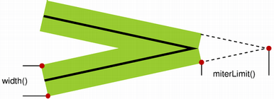

When the Qt::MiterJoin style is applied, it is possible to use the setMiterLimit() function to specify how far the miter join can extend from the join point. The miterLimit() is used to reduce artifacts between line joins where the lines are close to parallel.

The miterLimit() must be specified in units of the pens width, e.g. a miter limit of 5 in width 10 is 50 pixels long. The default miter limit is 2, i.e. twice the pen width in pixels.

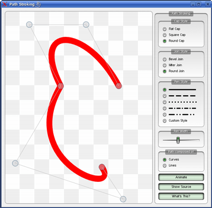

**[The Path Stroking Example](https://doc.qt.io/qt-5.15/qtwidgets-painting-pathstroke-example.html)**

The Path Stroking example shows Qt's built-in dash patterns and shows how custom patterns can be used to extend the range of available patterns.

**See also** QPainter, QBrush, [Path Stroking Example](https://doc.qt.io/qt-5.15/qtwidgets-painting-pathstroke-example.html), and [Scribble Example](https://doc.qt.io/qt-5.15/qtwidgets-widgets-scribble-example.html).

## Member Function Documentation

### QPen::QPen(QPen &&*pen*)

Constructs a pen that is moved from the given *pen*.

The moved-from pen can only be assigned to, copied, or destroyed. Any other operation (prior to assignment) leads to undefined behavior.

This function was introduced in Qt 5.4.

### QPen::QPen(const QPen &*pen*)

Constructs a pen that is a copy of the given *pen*.

### QPen::QPen(const QBrush &*brush*, qreal *width*, Qt::PenStyle *style* = Qt::SolidLine, Qt::PenCapStyle *cap* = Qt::SquareCap, Qt::PenJoinStyle *join* = Qt::BevelJoin)

Constructs a pen with the specified *brush*, *width*, pen *style*, *cap* style and *join* style.

**See also** setBrush(), setWidth(), setStyle(), setCapStyle(), and setJoinStyle().

### QPen::QPen(const QColor &*color*)

Constructs a solid line pen with 1 width and the given *color*.

**See also** setBrush() and setColor().

### QPen::QPen(Qt::PenStyle *style*)

Constructs a black pen with 1 width and the given *style*.

**See also** setStyle().

### QPen::QPen()

Constructs a default black solid line pen with 1 width.

### QPen &QPen::operator=(QPen &&*other*)

Move-assigns *other* to this QPen instance.

This function was introduced in Qt 5.2.

### QPen &QPen::operator=(const QPen &*pen*)

Assigns the given *pen* to this pen and returns a reference to this pen.

### QPen::~QPen()

Destroys the pen.

### QBrush QPen::brush() const

Returns the brush used to fill strokes generated with this pen.

**See also** setBrush().

### Qt::PenCapStyle QPen::capStyle() const

Returns the pen's cap style.

**See also** setCapStyle() and Cap Style.

### QColor QPen::color() const

Returns the color of this pen's brush.

**See also** brush() and setColor().

### qreal QPen::dashOffset() const

Returns the dash offset for the pen.

**See also** setDashOffset().

### QVector<qreal> QPen::dashPattern() const

Returns the dash pattern of this pen.

**See also** setDashPattern(), style(), and isSolid().

### bool QPen::isCosmetic() const

Returns `true` if the pen is cosmetic; otherwise returns `false`.

Cosmetic pens are used to draw strokes that have a constant width regardless of any transformations applied to the QPainter they are used with. Drawing a shape with a cosmetic pen ensures that its outline will have the same thickness at different scale factors.

A zero width pen is cosmetic by default.

**See also** setCosmetic() and widthF().

### bool QPen::isSolid() const

Returns `true` if the pen has a solid fill, otherwise false.

**See also** style() and dashPattern().

### Qt::PenJoinStyle QPen::joinStyle() const

Returns the pen's join style.

**See also** setJoinStyle() and Join Style.

### qreal QPen::miterLimit() const

Returns the miter limit of the pen. The miter limit is only relevant when the join style is set to Qt::MiterJoin.

**See also** setMiterLimit() and Join Style.

### void QPen::setBrush(const QBrush &*brush*)

Sets the brush used to fill strokes generated with this pen to the given *brush*.

**See also** brush() and setColor().

### void QPen::setCapStyle(Qt::PenCapStyle *style*)

Sets the pen's cap style to the given *style*. The default value is Qt::SquareCap.

**See also** capStyle() and Cap Style.

### void QPen::setColor(const QColor &*color*)

Sets the color of this pen's brush to the given *color*.

**See also** setBrush() and color().

### void QPen::setCosmetic(bool *cosmetic*)

Sets this pen to cosmetic or non-cosmetic, depending on the value of *cosmetic*.

**See also** isCosmetic().

### void QPen::setDashOffset(qreal *offset*)

Sets the dash offset (the starting point on the dash pattern) for this pen to the *offset* specified. The offset is measured in terms of the units used to specify the dash pattern.

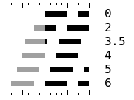

For example, a pattern where each stroke is four units long, followed by a gap of two units, will begin with the stroke when drawn as a line.

However, if the dash offset is set to 4.0, any line drawn will begin with the gap. Values of the offset up to 4.0 will cause part of the stroke to be drawn first, and values of the offset between 4.0 and 6.0 will cause the line to begin with part of the gap.

**Note:** This implicitly converts the style of the pen to Qt::CustomDashLine.

**See also** dashOffset().

### void QPen::setDashPattern(const QVector<qreal> &*pattern*)

Sets the dash pattern for this pen to the given *pattern*. This implicitly converts the style of the pen to Qt::CustomDashLine.

The pattern must be specified as an even number of positive entries where the entries 1, 3, 5... are the dashes and 2, 4, 6... are the spaces. For example:

```
QPen pen;
QVector<qreal> dashes;
qreal space = 4;
dashes << 1 << space << 3 << space << 9 << space
           << 27 << space << 9 << space;
pen.setDashPattern(dashes);
```

The dash pattern is specified in units of the pens width; e.g. a dash of length 5 in width 10 is 50 pixels long. Note that a pen with zero width is equivalent to a cosmetic pen with a width of 1 pixel.

Each dash is also subject to cap styles so a dash of 1 with square cap set will extend 0.5 pixels out in each direction resulting in a total width of 2.

Note that the default cap style is Qt::SquareCap, meaning that a square line end covers the end point and extends beyond it by half the line width.

**See also** setStyle(), dashPattern(), setCapStyle(), and setCosmetic().

### void QPen::setJoinStyle(Qt::PenJoinStyle *style*)

Sets the pen's join style to the given *style*. The default value is Qt::BevelJoin.

**See also** joinStyle() and Join Style.

### void QPen::setMiterLimit(qreal *limit*)

Sets the miter limit of this pen to the given *limit*.

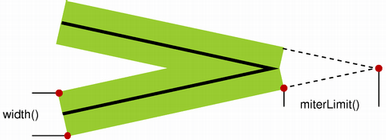

The miter limit describes how far a miter join can extend from the join point. This is used to reduce artifacts between line joins where the lines are close to parallel.

This value does only have effect when the pen style is set to Qt::MiterJoin. The value is specified in units of the pen's width, e.g. a miter limit of 5 in width 10 is 50 pixels long. The default miter limit is 2, i.e. twice the pen width in pixels.

**See also** miterLimit(), setJoinStyle(), and Join Style.

### void QPen::setStyle(Qt::PenStyle *style*)

Sets the pen style to the given *style*.

See the Qt::PenStyle documentation for a list of the available styles. Since Qt 4.1 it is also possible to specify a custom dash pattern using the setDashPattern() function which implicitly converts the style of the pen to Qt::CustomDashLine.

**Note:** This function resets the dash offset to zero.

**See also** style() and Pen Style.

### void QPen::setWidth(int *width*)

Sets the pen width to the given *width* in pixels with integer precision.

A line width of zero indicates a cosmetic pen. This means that the pen width is always drawn one pixel wide, independent of the transformation set on the painter.

Setting a pen width with a negative value is not supported.

**See also** setWidthF() and width().

### void QPen::setWidthF(qreal *width*)

Sets the pen width to the given *width* in pixels with floating point precision.

A line width of zero indicates a cosmetic pen. This means that the pen width is always drawn one pixel wide, independent of the transformation on the painter.

Setting a pen width with a negative value is not supported.

**See also** setWidth() and widthF().

### Qt::PenStyle QPen::style() const

Returns the pen style.

**See also** setStyle() and Pen Style.

### void QPen::swap(QPen &*other*)

Swaps pen *other* with this pen. This operation is very fast and never fails.

This function was introduced in Qt 4.8.

### int QPen::width() const

Returns the pen width with integer precision.

**See also** setWidth() and widthF().

### qreal QPen::widthF() const

Returns the pen width with floating point precision.

**See also** setWidthF() and width().

### QVariant QPen::operator QVariant() const

Returns the pen as a QVariant.

### bool QPen::operator!=(const QPen &*pen*) const

Returns `true` if the pen is different from the given *pen*; otherwise false. Two pens are different if they have different styles, widths or colors.

**See also** operator==().

### bool QPen::operator==(const QPen &*pen*) const

Returns `true` if the pen is equal to the given *pen*; otherwise false. Two pens are equal if they have equal styles, widths and colors.

**See also** operator!=().

## Related Non-Members

### QDataStream &operator<<(QDataStream &*stream*, const QPen &*pen*)

Writes the given *pen* to the given *stream* and returns a reference to the *stream*.

**See also** Serializing Qt Data Types.

### QDataStream &operator>>(QDataStream &*stream*, QPen &*pen*)

Reads a pen from the given *stream* into the given *pen* and returns a reference to the *stream*.

**See also** Serializing Qt Data Types.

© The Qt Company Ltd  
Licensed under the GNU Free Documentation License, Version 1.3.  
https://doc.qt.io/qt-5.15/qpen.html